# Demolition Survey Analysis

Mikayla Branz

# Import Data

```r
# Install package to be able to open Qualtrics csv file properly
#install.packages("qualtRics")
library(qualtRics)
library(tidyverse)
library(ggplot2)

#Open File
setwd("C:/Users/Mikayla Branz/Documents/Grad School Work/Jobs and Practica/DOH Practicum")
raw_demo_survey <- readSurvey("Demolition Opinions_October 5, 2020_09.45.csv")

View(raw_demo_survey)
```

# Clean Data

```r
#Remove random extra variables and identifying information
demoSurvey<- raw_demo_survey %>%
  select(-(1:7), -(9:17), -("Q9":"Q13"))

#Check and fix variable types
demoSurvey<- demoSurvey %>%
  mutate_at(vars(1,  "Q7", "Q8", "Q17"), list(as.character)) %>%
  mutate_at(vars("Q1", "Q4", "Q5", "Q6_1":"Q6_12", "Q14":"Q16"), list(as.factor))

#Remove empty survey attempts (didn't even fill out zip codes) and my practice attempt
demoSurvey <- demoSurvey %>%
  filter(Q1 != "NA", RecordedDate != "2020-08-26 11:04:41")
```

# 1. Summarize zip codes and parental status of survey respondents

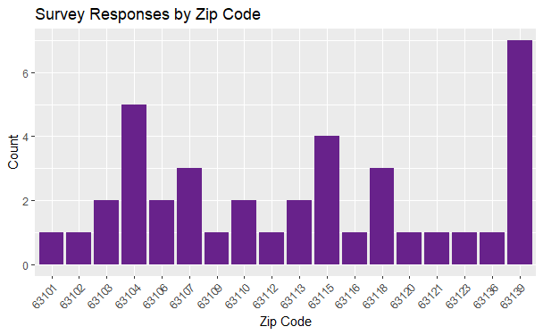

```r
ZipBar <- demoSurvey %>%
  ggplot(aes(x=Q1))+
  geom_bar(fill= "darkorchid4")+
  labs(x = "Zip Code", y = "Count", title = "Survey Responses by Zip Code")+
  theme(axis.text.x = element_text(angle = 45, vjust = 1, hjust = 1, ))

ZipBar
```

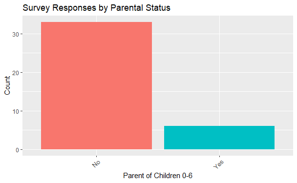

```r
ParentBar <- demoSurvey %>%
  ggplot(aes(x= Q4))+
  geom_bar(aes(fill=Q4), na.rm=FALSE)+
  labs(x = "Parent of Children 0-6", y = "Count", title = "Survey Responses by Parental Status", fill = "Parent of Children 0-6")+
  theme(legend.position = "none") +
  theme(axis.text.x = element_text(angle = 45, vjust = 1, hjust = 1, ))

ParentBar
```

```r
NA
```

# 2. Do you think demolitions cause health problems?

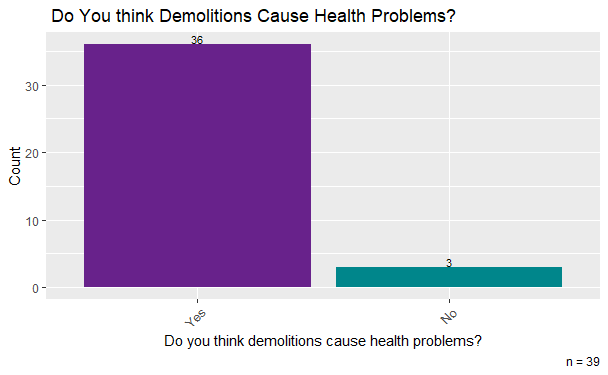

```r
#count number of responses not including NA
responsesQ5<- paste("n =", length(demoSurvey$Q5[!is.na(demoSurvey$Q5)]))

 newlevel <- c("Yes", "No")
 #change the order of the levels in race
 demoSurvey$Q5 <- factor(demoSurvey$Q5, levels = newlevel)

#Graph it
HealthProblemsBar <- demoSurvey %>%
  ggplot(aes(x= Q5))+
  geom_bar(aes(fill=Q5))+
   geom_text(aes(label=..count..),stat='count',position=position_dodge(0.9),vjust=-0.1, size = 3)+
  labs(x = "Do you think demolitions cause health problems?", y = "Count", title = " Do You think Demolitions Cause Health Problems?", fill = "Answer", caption = responsesQ5)+
  theme(axis.text.x = element_text(angle = 45, vjust = 1, hjust = 1, ))+
  theme(legend.position = "none") +
  scale_fill_manual(values = c("darkorchid4","turquoise4", "#02075d"))

HealthProblemsBar
```

# 3. What health problems do you think demolitions can cause?

```r
unique(demoSurvey$Q7)
```

```
 [1] "Issues related to breathing and the long term affects of radon, asbestos and lead poisoning."
 [2] "It depends on who is doing the demolition. If a company is public health focused, they will control for dust, contamination, etc."
 [3] "Asbestos, breathing the dust, lead paint dust and site safety."
 [4] "Mesothelioma and lung cancer"
 [5] "Unsafe lead demolition on old housing stock can lead to the spread of lead dust. This can lead to elevated blood lead levels which cause health and behavioral issues for children."
 [6] NA
 [7] "Spread of lead/asbestos dust, flare up existing health convictions like asthma, COPD."
 [8] "lead poisoning, issues with asbestos, asthma"
 [9] "Aggravate asthma or respiratory conditions. Depending on proximity the dust settles on surfaces that children use. The noise and lack of information is stressful."
[10] "Lead dust causes developmental issues in children. Other particles that are airborne can cause respiratory issues in all populations."
[11] "Increased lead levels, exposure to asbestos"
[12] "Breathing issues (specifically potential exposure to asbestos and lead, inhalants that trigger asthma), pollution, and environmental contamination"
[13] "Lead and dust in air, stress to nearby homeowners"
[14] "Lead poising\nTriggering asthma and other breathing issues\nPossible exposure to asbestos and its long-term health effects"
[15] "Contaminants released into the air (asbestos, lead paint)"
[16] "Hazardous particles that end up in drinking water, end up on the air we breathe, and end up in the soil that grows our food."
[17] "issues for lungs, lead and asbestos exposure, cancer causing chemicals"
[18] "asthma complications, lead dust in the air being inhaled, etc."
[19] "Lead spread and other toxic items like asbestos in demolitions can pollute the air, leaving the environment unsafe for nearby residents. Especially in areas like lung and brain development and allergies and asthma. For children this can mean learning disorders too as young brains are especiall…
[20] "asthma, lunch cancer, lead poisoning"
[21] "Dust can cause asthma problems.\nOlder buildings may have materials that are health hazards."
[22] "Ashtma, breathing problems, and cancer"
[23] "asthma, cancer, silicosis"
[24] "Asthma and respiratory issue, lead poisoning and related health issues, any unsanitary conditions can cause mold, bacteria and viruses to become airborne, potential injuries/cuts, asbestos/cancer"
[25] "Breathing Problems, Cancer"
[26] "Dust and asbestos sickness"
[27] "Lead poisoning, asthma and other URIs"
[28] "Asthma. Is airborne lead and asbestos an issue? Seems like it could be. Physical safety of unattended demolition sites."
[29] "The process of demolition can release toxic materials when friable.  E.g., old lead or asbestos in buildings."
[30] "A variety of issues in regards to environmental health."
```

# 4. Would you want to receive the following information or services?

### 4-1. A door hanger telling you a demolition will happen in a few months

[figure not shown]

```r
#count number of responses not including NA
responsesQ6_1<- paste("n =", length(demoSurvey$Q6_1[!is.na(demoSurvey$Q6_1)]))

# Change order of responses
newlevel <- c("Yes", "No", "Not sure")
 #change the order of the levels in race
 demoSurvey$Q6_1 <- factor(demoSurvey$Q6_1, levels = newlevel)

#Graph it
DoorHangerWeekBar <- demoSurvey %>%
  subset(!is.na(Q6_1)) %>%
ggplot(aes(x= Q6_1))+
  geom_bar(aes(fill=Q6_1))+
   geom_text(aes(label=..count..),stat='count',position=position_dodge(0.9),vjust=-0.1, size = 3)+
  labs(x = "Answer", y = "Count", title = paste(strwrap("Would you want to recieve a door hanger telling you a demolition will happen in a few months?", width = 55), collapse = "\n"), caption = responsesQ6_2)+
  theme(axis.text.x = element_text(angle = 45, vjust = 1, hjust = 1, ))+
  theme(legend.position = "none") +
   scale_fill_manual(values = c("darkorchid4","turquoise4", "#02075d"))+
  scale_x_discrete(drop=FALSE)

DoorHangerMonthsBar
```

### 4-2. A door hanger telling you a demolition will happen this week

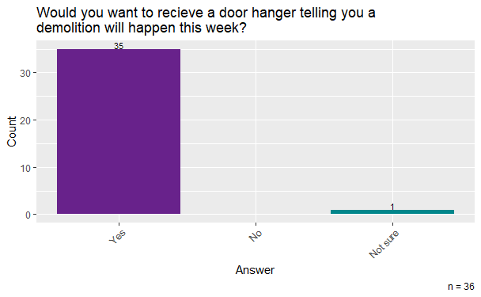

```r
#count number of responses not including NA
responsesQ6_2<- paste("n =", length(demoSurvey$Q6_2[!is.na(demoSurvey$Q6_2)]))

# Change order of responses
newlevel <- c("Yes", "No", "Not sure")
 #change the order of the levels in race
 demoSurvey$Q6_2 <- factor(demoSurvey$Q6_2, levels = newlevel)

#Graph it
DoorHangerWeekBar <- demoSurvey %>%
  subset(!is.na(Q6_2)) %>%
ggplot(aes(x= Q6_2))+
  geom_bar(aes(fill=Q6_2))+
   geom_text(aes(label=..count..),stat='count',position=position_dodge(0.9),vjust=-0.1, size = 3)+
  labs(x = "Answer", y = "Count", title = paste(strwrap("Would you want to recieve a door hanger telling you a demolition will happen this week?", width = 55), collapse = "\n"), caption = responsesQ6_2)+
  theme(axis.text.x = element_text(angle = 45, vjust = 1, hjust = 1, ))+
  theme(legend.position = "none") +
   scale_fill_manual(values = c("darkorchid4","turquoise4", "#02075d")) +
    scale_x_discrete(drop=FALSE)

DoorHangerWeekBar
```

### 4-3. A text message alert telling you a demolition will happen in a few months?

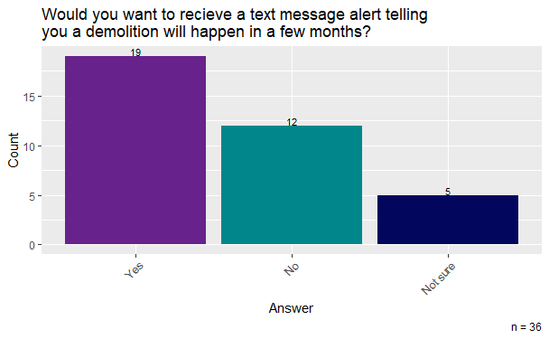

```r
#count number of responses not including NA
responsesQ6_3<- paste("n =", length(demoSurvey$Q6_3[!is.na(demoSurvey$Q6_3)]))

# Change order of responses
newlevel <- c("Yes", "No", "Not sure")
 #change the order of the levels in race
 demoSurvey$Q6_3 <- factor(demoSurvey$Q6_3, levels = newlevel)

#Graph it
TextMonthsBar <- demoSurvey %>%
  subset(!is.na(Q6_3)) %>%
ggplot(aes(x= Q6_3))+
  geom_bar(aes(fill=Q6_3))+
   geom_text(aes(label=..count..),stat='count',position=position_dodge(0.9),vjust=-0.1, size = 3)+
  labs(x = "Answer", y = "Count", title = paste(strwrap("Would you want to recieve a text message alert telling you a demolition will happen in a few months?", width = 55), collapse = "\n"), caption = responsesQ6_3)+
  theme(axis.text.x = element_text(angle = 45, vjust = 1, hjust = 1, ))+
  theme(legend.position = "none") +
   scale_fill_manual(values = c("darkorchid4","turquoise4", "#02075d")) +
    scale_x_discrete(drop=FALSE)

TextMonthsBar
```

### 4-4. A text message alert telling you a demolition will happen this week?

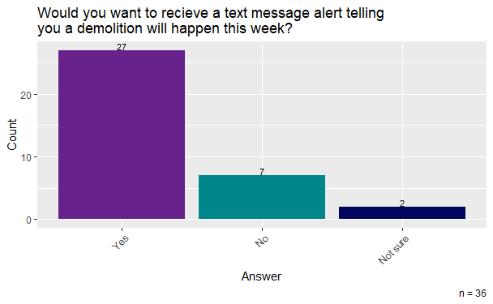

```r
#count number of responses not including NA
responsesQ6_4<- paste("n =", length(demoSurvey$Q6_4[!is.na(demoSurvey$Q6_4)]))

# Change order of responses
newlevel <- c("Yes", "No", "Not sure")
 #change the order of the levels in race
 demoSurvey$Q6_4 <- factor(demoSurvey$Q6_4, levels = newlevel)

#Graph it
TextWeekBar <- demoSurvey %>%
  subset(!is.na(Q6_4)) %>%
ggplot(aes(x= Q6_4))+
  geom_bar(aes(fill=Q6_4))+
   geom_text(aes(label=..count..),stat='count',position=position_dodge(0.9),vjust=-0.1, size = 3)+
  labs(x = "Answer", y = "Count", title = paste(strwrap("Would you want to recieve a text message alert telling you a demolition will happen this week?", width = 55), collapse = "\n"), caption = responsesQ6_4)+
  theme(axis.text.x = element_text(angle = 45, vjust = 1, hjust = 1, ))+
  theme(legend.position = "none") +
   scale_fill_manual(values = c("darkorchid4","turquoise4", "#02075d")) +
    scale_x_discrete(drop=FALSE)

TextWeekBar
```

### 4-5. A text message alert telling you a demolition will happen tomorrow?

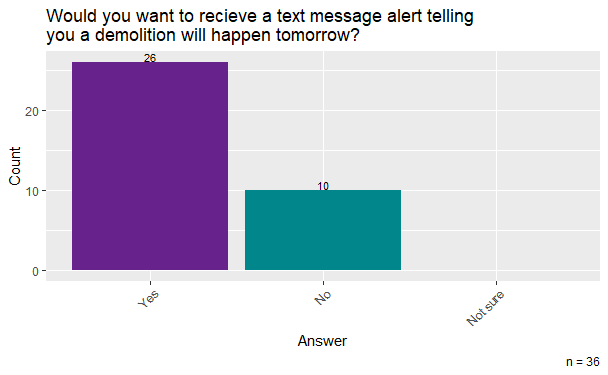

```r
#count number of responses not including NA
responsesQ6_5<- paste("n =", length(demoSurvey$Q6_5[!is.na(demoSurvey$Q6_5)]))

# Change order of responses
newlevel <- c("Yes", "No", "Not sure")
 #change the order of the levels in race
 demoSurvey$Q6_5 <- factor(demoSurvey$Q6_5, levels = newlevel)

#Graph it
TextTomorrowBar <- demoSurvey %>%
  subset(!is.na(Q6_5)) %>%
ggplot(aes(x= Q6_5))+
  geom_bar(aes(fill=Q6_5))+
   geom_text(aes(label=..count..),stat='count',position=position_dodge(0.9),vjust=-0.1, size = 3)+
  labs(x = "Answer", y = "Count", title = paste(strwrap("Would you want to recieve a text message alert telling you a demolition will happen tomorrow?", width = 55), collapse = "\n"), caption = responsesQ6_5)+
  theme(axis.text.x = element_text(angle = 45, vjust = 1, hjust = 1, ))+
  theme(legend.position = "none") +
   scale_fill_manual(values = c("darkorchid4","turquoise4", "#02075d")) +
    scale_x_discrete(drop=FALSE)

TextTomorrowBar
```

### 4-6. A visit by a lead expert or a lead advocate to explain how to protect children from lead released in demolitions?

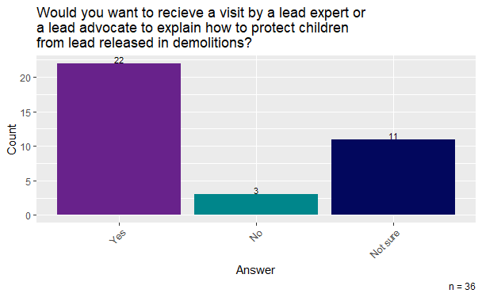

```r
#count number of responses not including NA
responsesQ6_6<- paste("n =", length(demoSurvey$Q6_6[!is.na(demoSurvey$Q6_6)]))

# Change order of responses
newlevel <- c("Yes", "No", "Not sure")
 #change the order of the levels in race
 demoSurvey$Q6_6 <- factor(demoSurvey$Q6_6, levels = newlevel)

#Graph it
LeadAdvocateBar <- demoSurvey %>%
  subset(!is.na(Q6_6)) %>%
ggplot(aes(x= Q6_6))+
  geom_bar(aes(fill=Q6_6))+
   geom_text(aes(label=..count..),stat='count',position=position_dodge(0.9),vjust=-0.1, size = 3)+
  labs(x = "Answer", y = "Count", title = paste(strwrap("Would you want to recieve a visit by a lead expert or a lead advocate to explain how to protect children from lead released in demolitions?", width = 55), collapse = "\n"), caption = responsesQ6_6)+
  theme(axis.text.x = element_text(angle = 45, vjust = 1, hjust = 1, ))+
  theme(legend.position = "none") +
   scale_fill_manual(values = c("darkorchid4","turquoise4", "#02075d")) +
    scale_x_discrete(drop=FALSE)

LeadAdvocateBar
```

#### 4-6.1 Parents only: A visit by a lead expert or a lead advocate to explain how to protect children from lead released in demolitions?

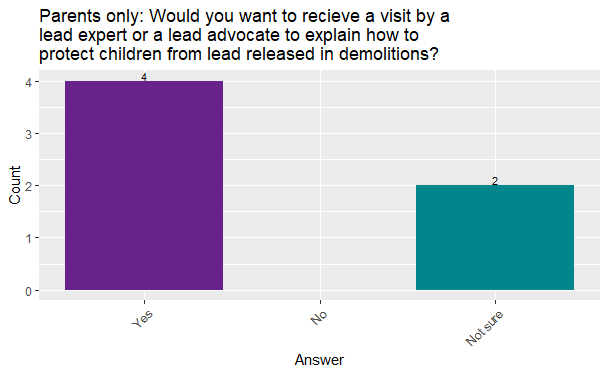

```r
#Graph it
ParentsLeadAdvocateBar <- demoSurvey %>%
  subset(!is.na(Q6_6)) %>%
  filter(Q4 == "Yes") %>%
ggplot(aes(x= Q6_6))+
  geom_bar(aes(fill=Q6_6))+
   geom_text(aes(label=..count..),stat='count',position=position_dodge(0.9),vjust=-0.1, size = 3)+
  labs(x = "Answer", y = "Count", title = paste(strwrap("Parents only: Would you want to recieve a visit by a lead expert or a lead advocate to explain how to protect children from lead released in demolitions?", width = 55), collapse = "\n"))+
  theme(axis.text.x = element_text(angle = 45, vjust = 1, hjust = 1, ))+
  theme(legend.position = "none") +
   scale_fill_manual(values = c("darkorchid4","turquoise4", "#02075d")) +
    scale_x_discrete(drop=FALSE)

ParentsLeadAdvocateBar
```

### 4-7. A protective mat and vacuum to keep lead dust out of your home?

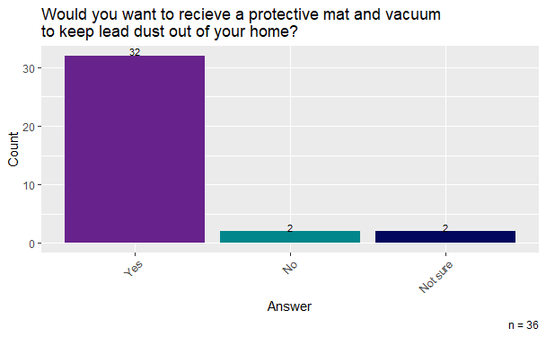

```r
#count number of responses not including NA
responsesQ6_7<- paste("n =", length(demoSurvey$Q6_7[!is.na(demoSurvey$Q6_7)]))

# Change order of responses
newlevel <- c("Yes", "No", "Not sure")
 #change the order of the levels in race
 demoSurvey$Q6_7 <- factor(demoSurvey$Q6_7, levels = newlevel)

#Graph it
MatVacuumBar <- demoSurvey %>%
  subset(!is.na(Q6_7)) %>%
ggplot(aes(x= Q6_7))+
  geom_bar(aes(fill=Q6_7))+
   geom_text(aes(label=..count..),stat='count',position=position_dodge(0.9),vjust=-0.1, size = 3)+
  labs(x = "Answer", y = "Count", title = paste(strwrap("Would you want to recieve a protective mat and vacuum to keep lead dust out of your home?", width = 55), collapse = "\n"), caption = responsesQ6_7)+
  theme(axis.text.x = element_text(angle = 45, vjust = 1, hjust = 1, ))+
  theme(legend.position = "none") +
   scale_fill_manual(values = c("darkorchid4","turquoise4", "#02075d")) +
    scale_x_discrete(drop=FALSE)

MatVacuumBar
```

### 4-8. A hotline you could call to find out if a demolition is going to happen soon near you?

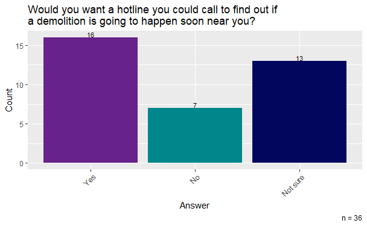

```r
#count number of responses not including NA
responsesQ6_8<- paste("n =", length(demoSurvey$Q6_8[!is.na(demoSurvey$Q6_8)]))

# Change order of responses
newlevel <- c("Yes", "No", "Not sure")
 #change the order of the levels in race
 demoSurvey$Q6_8 <- factor(demoSurvey$Q6_8, levels = newlevel)

#Graph it
HotlineBar <- demoSurvey %>%
  subset(!is.na(Q6_8)) %>%
ggplot(aes(x= Q6_8))+
  geom_bar(aes(fill=Q6_8))+
   geom_text(aes(label=..count..),stat='count',position=position_dodge(0.9),vjust=-0.1, size = 3)+
  labs(x = "Answer", y = "Count", title = paste(strwrap("Would you want a hotline you could call to find out if a demolition is going to happen soon near you?", width = 55), collapse = "\n"), caption = responsesQ6_8)+
  theme(axis.text.x = element_text(angle = 45, vjust = 1, hjust = 1, ))+
  theme(legend.position = "none") +
   scale_fill_manual(values = c("darkorchid4","turquoise4", "#02075d")) +
    scale_x_discrete(drop=FALSE)

HotlineBar
```

### 4-9. A hotline you could call to report dust coming off a demolition or safety concerns?

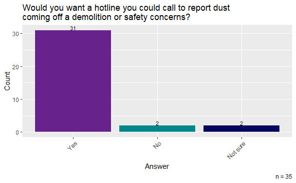

```r
#count number of responses not including NA
responsesQ6_9<- paste("n =", length(demoSurvey$Q6_9[!is.na(demoSurvey$Q6_9)]))

# Change order of responses
newlevel <- c("Yes", "No", "Not sure")
 #change the order of the levels in race
 demoSurvey$Q6_9 <- factor(demoSurvey$Q6_9, levels = newlevel)

#Graph it
HotlineReportBar <- demoSurvey %>%
  subset(!is.na(Q6_9)) %>%
ggplot(aes(x= Q6_9))+
  geom_bar(aes(fill=Q6_9))+
   geom_text(aes(label=..count..),stat='count',position=position_dodge(0.9),vjust=-0.1, size = 3)+
  labs(x = "Answer", y = "Count", title = paste(strwrap("Would you want a hotline you could call to report dust coming off a demolition or safety concerns?", width = 55), collapse = "\n"), caption = responsesQ6_9)+
  theme(axis.text.x = element_text(angle = 45, vjust = 1, hjust = 1, ))+
  theme(legend.position = "none") +
   scale_fill_manual(values = c("darkorchid4","turquoise4", "#02075d")) +
    scale_x_discrete(drop=FALSE)

HotlineReportBar
```

### 4-10. A website where you could look up where demolitions are going to happen?

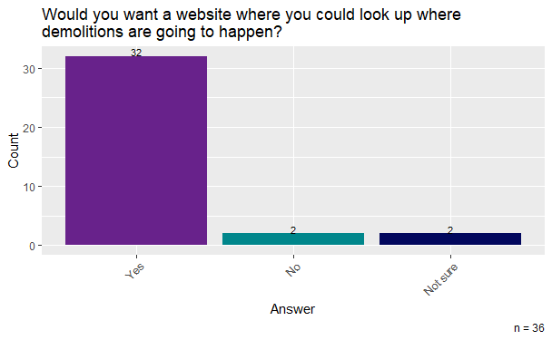

```r
#count number of responses not including NA
responsesQ6_10<- paste("n =", length(demoSurvey$Q6_10[!is.na(demoSurvey$Q6_10)]))

# Change order of responses
newlevel <- c("Yes", "No", "Not sure")
 #change the order of the levels in race
 demoSurvey$Q6_10 <- factor(demoSurvey$Q6_10, levels = newlevel)

#Graph it
WebsiteReportBar <- demoSurvey %>%
  subset(!is.na(Q6_10)) %>%
ggplot(aes(x= Q6_10))+
  geom_bar(aes(fill=Q6_10))+
   geom_text(aes(label=..count..),stat='count',position=position_dodge(0.9),vjust=-0.1, size = 3)+
  labs(x = "Answer", y = "Count", title = paste(strwrap("Would you want a website where you could look up where demolitions are going to happen?", width = 55), collapse = "\n"), caption = responsesQ6_10)+
  theme(axis.text.x = element_text(angle = 45, vjust = 1, hjust = 1, ))+
  theme(legend.position = "none") +
   scale_fill_manual(values = c("darkorchid4","turquoise4", "#02075d")) +
    scale_x_discrete(drop=FALSE)

WebsiteReportBar
```

### 4-11. A website with informationabout how to protect yourself and your family from demolition dust?

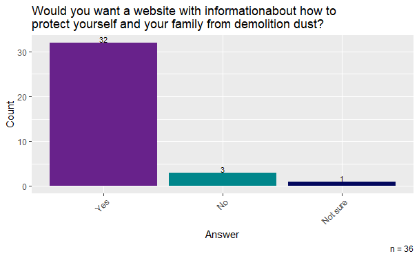

```r
#count number of responses not including NA
responsesQ6_11<- paste("n =", length(demoSurvey$Q6_11[!is.na(demoSurvey$Q6_11)]))

# Change order of responses
newlevel <- c("Yes", "No", "Not sure")
 #change the order of the levels in race
 demoSurvey$Q6_11 <- factor(demoSurvey$Q6_11, levels = newlevel)

#Graph it
WebsiteInfoBar <- demoSurvey %>%
  subset(!is.na(Q6_11)) %>%
ggplot(aes(x= Q6_11))+
  geom_bar(aes(fill=Q6_11))+
   geom_text(aes(label=..count..),stat='count',position=position_dodge(0.9),vjust=-0.1, size = 3)+
  labs(x = "Answer", y = "Count", title = paste(strwrap("Would you want a website with informationabout how to protect yourself and your family from demolition dust?", width = 55), collapse = "\n"), caption = responsesQ6_11)+
  theme(axis.text.x = element_text(angle = 45, vjust = 1, hjust = 1, ))+
  theme(legend.position = "none") +
   scale_fill_manual(values = c("darkorchid4","turquoise4", "#02075d")) +
    scale_x_discrete(drop=FALSE)

WebsiteInfoBar
```

### 4-12. A flyer at your door with information about how to protect yourself and your family from demolition dust?

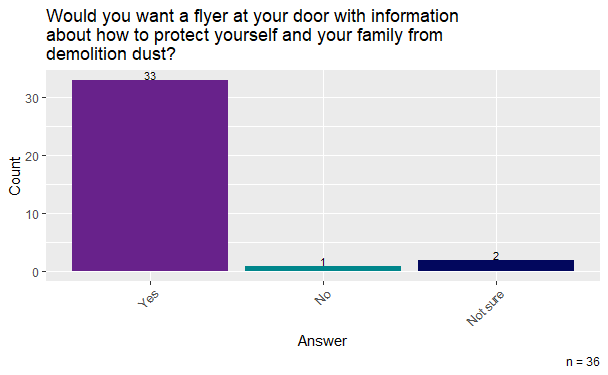

```r
#count number of responses not including NA
responsesQ6_12<- paste("n =", length(demoSurvey$Q6_12[!is.na(demoSurvey$Q6_12)]))

# Change order of responses
newlevel <- c("Yes", "No", "Not sure")
 #change the order of the levels in race
 demoSurvey$Q6_12 <- factor(demoSurvey$Q6_12, levels = newlevel)

#Graph it
FlyerBar <- demoSurvey %>%
  subset(!is.na(Q6_12)) %>%
ggplot(aes(x= Q6_12))+
  geom_bar(aes(fill=Q6_12))+
   geom_text(aes(label=..count..),stat='count',position=position_dodge(0.9),vjust=-0.1, size = 3)+
  labs(x = "Answer", y = "Count", title = paste(strwrap("Would you want a flyer at your door with information about how to protect yourself and your family from demolition dust?", width = 55), collapse = "\n"), caption = responsesQ6_12)+
  theme(axis.text.x = element_text(angle = 45, vjust = 1, hjust = 1, ))+
  theme(legend.position = "none") +
   scale_fill_manual(values = c("darkorchid4","turquoise4", "#02075d")) +
    scale_x_discrete(drop=FALSE)

FlyerBar
```

# 5. What other information would you would want to receive about demolitions happening in your neighborhood?

```r
unique(demoSurvey$Q8)
```

```
 [1] "A notification about on street parking should also be provided during the affected days."
 [2] "If affected by demolition (eg. asthma symptoms), steps to follow and contact info."
 [3] "Mainly an advance warning of the demolition and precautions that would be in place."
 [4] NA
 [5] "I would want to know the number for construction site inspectors who are supposed to monitor sites and hold companies accountable."
 [6] "Estimate time frames for demos and future demos near my home"
 [7] "What the rules are so that we can hold contractors accountable."
 [8] "I indicated \"not sure\" for the hotline; utilizing the CSB seems sufficient."
 [9] "Contact with demo company on when it will occur- a phone number maybe?"
[10] "As a neighbor, I would want to know what I can do as \"eyes and ears on the street\" to see that the demo is done properly.  What would I need to know to look for that would tell me the demo contractor is cutting corners and putting neighbors' health and safety at risk?  And if I see malpracti…
[11] "Any other safety concerns. Street or alley closures."
[12] "The way you phrase your questions will garner biased responses. No one will ever say no to more notice/warning"
[13] "Information on how to/hotline number to call and report if demolitions are not happening as they should (such as those doing the demolitions not hosing down the debris so that dust, asbestos, and lead does not travel)."
[14] "I would like really good reasoning as to WHY it's happening. I MUCH prefer that the historic houses and buildings in my neighborhood be left alone and NOT demo-ed (even the ones in horrible condition) so that they can possibly be rehabbed in the future."
[15] "I would want not just a hotline but a way to photograph and submit violations that are being made before an inspector arrives. I’ve seen entire houses torn down without a sprayer before an inspector responds to a call. There must be consequences and I’d want to see on a website who is doing th…
[16] "information on why it is important to know about demolitions- \nwhat does a proper demolition look like\n"
[17] "The demolition company owner's name and phone number"
[18] "What’s going to happen with the vacant lot."
[19] "Have someone attend neighborhood meetings to let people know what is happening"
[20] "Detail concerning what the demo contractor will be doing to control the dust and the role the building division will do to insure safety."
[21] "Where it was happening and what companies were doing the work."
[22] "Definitely like the ideas that are put in my face in different ways vs. me having to go out and find the information myself or think to go looking."
[23] "I woulf like info on services and shelters for unhoused people who are usually displaced by demolitions."
```

# 6. Did you know that demolition contractors are supposed to spray the demolition site with water during a demolition?

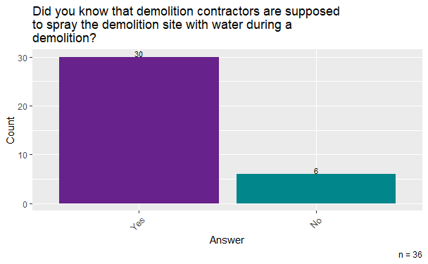

```r
#count number of responses not including NA
responsesQ14<- paste("n =", length(demoSurvey$Q14[!is.na(demoSurvey$Q14)]))

# Change order of responses
newlevel <- c("Yes", "No")
 #change the order of the levels in race
 demoSurvey$Q14 <- factor(demoSurvey$Q14, levels = newlevel)

#Graph it
KnewSprayingBar<- demoSurvey %>%
  subset(!is.na(Q14)) %>%
ggplot(aes(x= Q14))+
  geom_bar(aes(fill=Q14))+
   geom_text(aes(label=..count..),stat='count',position=position_dodge(0.9),vjust=-0.1, size = 3)+
  labs(x = "Answer", y = "Count", title = paste(strwrap("Did you know that demolition contractors are supposed to spray the demolition site with water during a demolition?", width = 55), collapse = "\n"), caption = responsesQ14)+
  theme(axis.text.x = element_text(angle = 45, vjust = 1, hjust = 1, ))+
  theme(legend.position = "none") +
   scale_fill_manual(values = c("darkorchid4","turquoise4", "#02075d")) +
    scale_x_discrete(drop=FALSE)

KnewSprayingBar
```

# 7. When there is a demolition in your neighborhood, how often do you see them spraying water on the building while they knock it down?

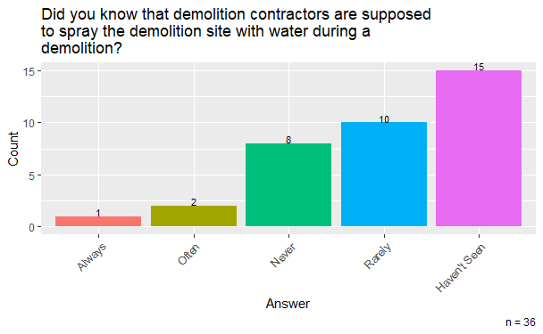

```r
#count number of responses not including NA
responsesQ19<- paste("n =", length(demoSurvey$Q19[!is.na(demoSurvey$Q19)]))

#Rename haven't seen
demoSurvey$Q19 <- recode(demoSurvey$Q19,"I haven't seen a demolition in my neighborhood" = "Haven't Seen")

# Change order of responses
newlevel <- c("Always", "Often", "Never", "Rarely", "Haven't Seen")
 #change the order of the levels in race
 demoSurvey$Q19 <- factor(demoSurvey$Q19, levels = newlevel)

#Graph it
SeeSprayingBar <- demoSurvey %>%
  subset(!is.na(Q19)) %>%
ggplot(aes(x= Q19))+
  geom_bar(aes(fill=Q19))+
   geom_text(aes(label=..count..),stat='count',position=position_dodge(0.9),vjust=-0.1, size = 3)+
  labs(x = "Answer", y = "Count", title = paste(strwrap("Did you know that demolition contractors are supposed to spray the demolition site with water during a demolition?", width = 55), collapse = "\n"), caption = responsesQ19)+
  theme(axis.text.x = element_text(angle = 45, vjust = 1, hjust = 1, ))+
  theme(legend.position = "none") +
    scale_x_discrete(drop=FALSE)

SeeSprayingBar
```

# 8. Did you know you can call the Citizens’ Service Bureau (CSB) at 314-622-4800 to report a contractor who doing a demolition without spraying water on it?

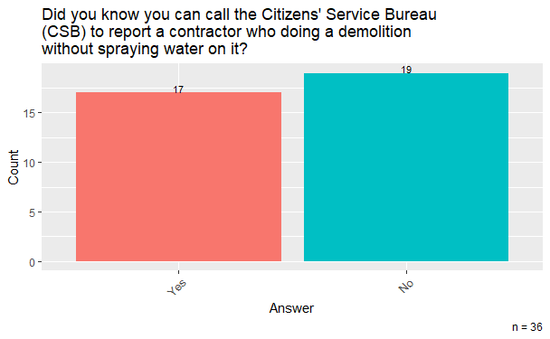

```r
#count number of responses not including NA
responsesQ15<- paste("n =", length(demoSurvey$Q15[!is.na(demoSurvey$Q15)]))

# Change order of responses
newlevel <- c("Yes", "No")
 #change the order of the levels in race
 demoSurvey$Q15 <- factor(demoSurvey$Q15, levels = newlevel)

#Graph it
KnewCSBBar <- demoSurvey %>%
  subset(!is.na(Q15)) %>%
ggplot(aes(x= Q15))+
  geom_bar(aes(fill=Q15))+
   geom_text(aes(label=..count..),stat='count',position=position_dodge(0.9),vjust=-0.1, size = 3)+
  labs(x = "Answer", y = "Count", title = paste(strwrap("Did you know you can call the Citizens' Service Bureau (CSB) to report a contractor who doing a demolition without spraying water on it?", width = 55), collapse = "\n"), caption = responsesQ15)+
  theme(axis.text.x = element_text(angle = 45, vjust = 1, hjust = 1, ))+
  theme(legend.position = "none") +
    scale_x_discrete(drop=FALSE)

KnewCSBBar
```

# 9. In the future, how likely are you to call the Citizens’ Service Bureau to report a contractor who is not spraying water on a demolition?

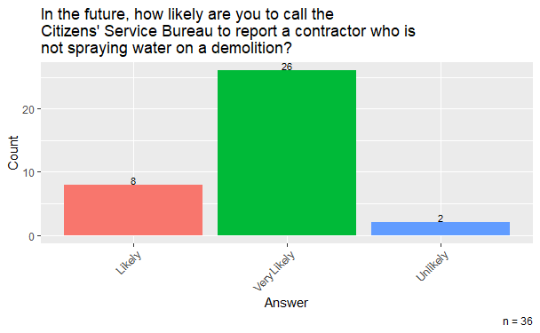

```r
#count number of responses not including NA
responsesQ16<- paste("n =", length(demoSurvey$Q16[!is.na(demoSurvey$Q16)]))

# Change order of responses
newlevel <- c("Likely", "Very Likely", "Unlikely")
 #change the order of the levels in race
 demoSurvey$Q16 <- factor(demoSurvey$Q16, levels = newlevel)

#Graph it
LikelyCallBar <- demoSurvey %>%
  subset(!is.na(Q16)) %>%
ggplot(aes(x= Q16))+
  geom_bar(aes(fill=Q16))+
   geom_text(aes(label=..count..),stat='count',position=position_dodge(0.9),vjust=-0.1, size = 3)+
  labs(x = "Answer", y = "Count", title = paste(strwrap("In the future, how likely are you to call the Citizens' Service Bureau to report a contractor who is not spraying water on a demolition?", width = 55), collapse = "\n"), caption = responsesQ16)+
  theme(axis.text.x = element_text(angle = 45, vjust = 1, hjust = 1, ))+
  theme(legend.position = "none") +
    scale_x_discrete(drop=FALSE)

LikelyCallBar
```

## 10. Please explain why

### Respondents who said they were likely to call

```r
demoLikely<- demoSurvey %>%
  filter(Q16 == "Likely")

unique(demoLikely$Q17, na.rm = TRUE)
```

```
[1] NA
[2] "Now I have the information."
[3] "Because I didn't know who to call before to report."
```

### Respondents who said they were very likely to call

```r
demoVeryLikely<- demoSurvey %>%
  filter(Q16 == "Very Likely")

unique(demoVeryLikely$Q17)
```

```
 [1] NA
 [2] "I'm a block captain and involved with several community organizations. I am usually the one contacted when neighbors have concerns."
 [3] "One companies misconduct can cause negative health outcomes for the high risk zip codes."
 [4] "Because I now know what to look for and can report it"
 [5] "Contractors who are violating guidelines are willingly putting communities in danger."
 [6] "Failure to follow safe demolition practices has poses an immediate threat to public health."
 [7] "We had 4 buildings demolished next door to me.  None were sprayed.  City was called multiple times but still no spraying.  Dust was all over my home, trees and duct work.  I had an infant living with me at the time."
 [8] "Not spraying water at a demo site puts all the neighbors at risk.  The contractors should get used to this requirement.  I am afraid they never will unless they know that they will be penalized for not complying."
 [9] "Knowing who to call is helpful"
[10] "Because this is dangerous and they should be held accountable by the city if they are trusted to do this job."
[11] "I don't approve of demolitions at all and I want to make it as miserable and difficult for all parties involved as possible.  And I don't want them doing it improperly."
[12] "I have driven in neighborhoods with demolitions and when they don’t have a sprayer I have contacted the CSB to report it. Even if they aren’t cited I will not stop until someone takes this seriously."
[13] "Because I have 2 children and a husband with asthma. I also live near the future NGA and when they demolished that area and dumped the remains by my kids school, my daughter ended up on a second inhaler."
[14] "I would do that now."
[15] "Because we must keep them accountable."
[16] "I never have a problem reporting wrongdoings that could cause harm to others"
```

```r
demoUnlikely<- demoSurvey %>%
  filter(Q16 == "Likely")

unique(demoUnlikely$Q17)
```

```
[1] NA
[2] "Now I have the information."
[3] "Because I didn't know who to call before to report."
```